# 13-vcfr

2023-05-24

# 13-vcfr

In this notebook we’ll apply some final filtering, compute some simple trees, and briefly look at any structure. I don’t expect to be doing much popgen with this work.

```r
library(vcfR)
library(tidyverse)
```

So we have out metadata

```r
reseq <- readr::read_tsv("input/resequencing.tsv")
# There are a couple that didn't have SRA numbers
# So i made temporary ids for them.
reseq[["id"]] <- reseq[["sra"]]
reseq[reseq$accession == "Sscl-Lang", "id"] <- "SSCLLANG"
reseq[reseq$accession == "Sscl-Lmut", "id"] <- "SSCLLMUT"
reseq[reseq$accession == "LC41", "id"] <- "SSCLLC41"
tail(reseq)
```

```
## # A tibble: 6 × 15
##   sra    bioproject biosample DOI   url   platform read_length strategy organism
##   <chr>  <chr>      <chr>     <chr> <chr> <chr>          <dbl> <chr>    <chr>
## 1 SRR42… PRJNA3427… SAMN0576… http… <NA>  ILLUMINA         100 PE       Sclerot…
## 2 ERR47… PRJEB36746 SAMEA654… http… <NA>  ILLUMINA         100 PE       Sclerot…
## 3 SRR14… PRJNA7228… SAMN1879… http… <NA>  ILLUMINA         150 PE       Sclerot…
## 4 <NA>   <NA>       <NA>      http… http… MGISEQ            NA PE       Sclerot…
## 5 <NA>   PRJNA4492… SAMN0889… http… <NA>  ILLUMINA         250 PE       Sclerot…
## 6 <NA>   PRJNA4492… SAMN0889… http… <NA>  ILLUMINA         250 PE       Sclerot…
## # ℹ 6 more variables: accession <chr>, collection_host <chr>,
## #   collection_location <chr>, collection_year <dbl>, Notes <chr>, id <chr>
```

First, i know that there are a few isolates that aren’t sclerotinia sclerotiorum.

```r
reseq %>% filter(organism != "Sclerotinia sclerotiorum")
```

```
## # A tibble: 3 × 15
##   sra    bioproject biosample DOI   url   platform read_length strategy organism
##   <chr>  <chr>      <chr>     <chr> <chr> <chr>          <dbl> <chr>    <chr>
## 1 SRR86… PRJNA5169… SAMN1084… http… <NA>  ILLUMINA         125 PE       Sclerot…
## 2 ERR47… PRJEB36746 SAMEA654… http… <NA>  ILLUMINA         100 PE       Sclerot…
## 3 <NA>   <NA>       <NA>      http… http… MGISEQ            NA PE       Sclerot…
## # ℹ 6 more variables: accession <chr>, collection_host <chr>,
## #   collection_location <chr>, collection_year <dbl>, Notes <chr>, id <chr>
```

These will serve as an outgroup later.

```r
# These are not Sclerotiorum
non_sclerotiorum <- c("SRR8608049", "ERR4705209", "SSCLLC41")
```

Now i’m loading the variants. I’ll apply the filters that are already in the data. Normally i’d keep them a soft-filtered variants, but it’ll be easier for everyone not to have to worry about that. We can check with the original one later if we need to.

```r
vcf <- read.vcfR(file = "output/snpeff/final-snpeff.vcf.gz")
```

[output not shown]

[output cut: 427 more lines]

[output not shown]

```r
vcf <- vcf[vcf@fix[, "FILTER"] == "PASS" | vcf@fix[, "FILTER"] == "."]
vcf
```

```
## ***** Object of Class vcfR *****
## 36 samples
## 16 CHROMs
## 351,595 variants
## Object size: 478.5 Mb
## 0 percent missing data
## *****        *****         *****
```

So, we’ve got ~350k variant loci.

```r
# These isolates are accidental duplicates
vcf@gt <- vcf@gt[, !attr(vcf@gt, "dimnames")[[2]] %in% c("SRR8485440", "SRR8485438", "SRR8485439", "SRR8485442")]
vcf
```

```
## ***** Object of Class vcfR *****
## 32 samples
## 16 CHROMs
## 351,595 variants
## Object size: 467.8 Mb
## 0 percent missing data
## *****        *****         *****
```

First i’ll say that any variants with low DP are not assigned.

```r
dp <- extract.gt(vcf, element = "DP", as.numeric=TRUE)
vcf@gt[dp < 4] <- NA
```

Here’s a plot of the amount of missing data per sample.

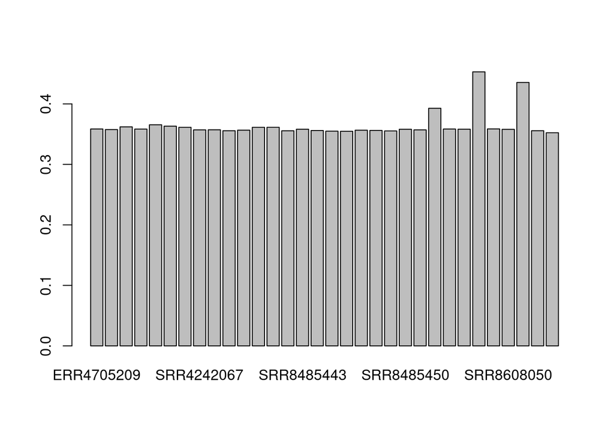

```r
dp <- extract.gt(vcf, element = "DP", as.numeric=TRUE)
barplot(apply(is.na(dp), MARGIN = 2, FUN = function(x) sum(x, na.rm = TRUE)) / nrow(dp))
```

Most are below 0.4 and all below 0.5, even including the non-sclerotiorum isolates. That’s not too bad.

Normally i’d be harder on threshold for phylogenetics, but we’ll go harder later on.

Now let’s see how many variants have lots of missing data.

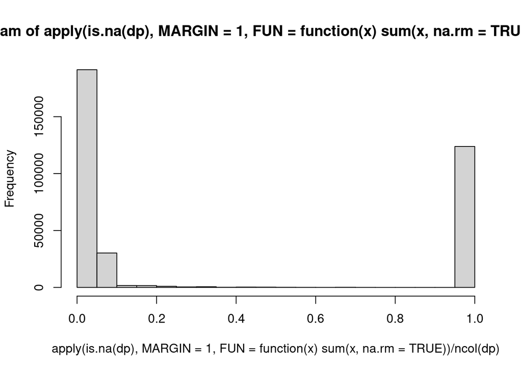

```r
hist(apply(is.na(dp), MARGIN = 1, FUN = function(x) sum(x, na.rm = TRUE)) / ncol(dp))
```

```r
vcf <- vcf[(apply(is.na(dp), MARGIN = 1, FUN = function(x) sum(x, na.rm = TRUE)) / ncol(dp)) < 0.5]
vcf
```

```
## ***** Object of Class vcfR *****
## 32 samples
## 16 CHROMs
## 227,258 variants
## Object size: 303.2 Mb
## 1.744 percent missing data
## *****        *****         *****
```

Let’s look at missing data per isolate again.

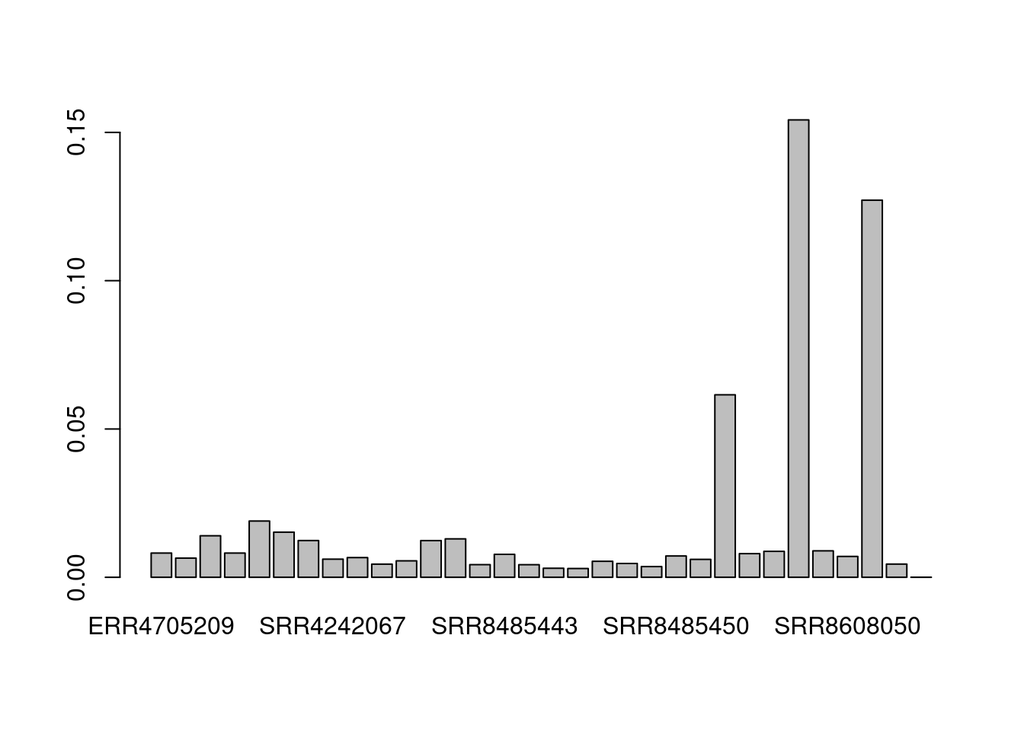

```r
dp <- extract.gt(vcf, element = "DP", as.numeric=TRUE)
barplot(apply(is.na(dp), MARGIN = 2, FUN = function(x) sum(x, na.rm = TRUE)) / nrow(dp))
```

Much better. Again, we’ve got a few with more missing data, but it’s really not that much considering they’re different species.

After setting things with DP < 4 to NA, we might have some loci that are all the same loci that are all reference genotype. Here i’m removing those loci.

```r
gt <- extract.gt(vcf, element = "GT", as.numeric=TRUE)
vcf <- vcf[!apply(gt == 0, MARGIN = 1, FUN = function(x) all(x, na.rm = TRUE))]
vcf
```

```
## ***** Object of Class vcfR *****
## 32 samples
## 16 CHROMs
## 219,102 variants
## Object size: 293.5 Mb
## 1.502 percent missing data
## *****        *****         *****
```

Let’s see how many loci are the same as the reference per-isolate.

```r
gt <- extract.gt(vcf, element = "GT", as.numeric=TRUE)
sort(apply((gt == 0), MARGIN = 2, FUN = function(x) sum(x, na.rm = TRUE)))
```

```
##  SRR8608048  SRR8608049    SSCLLC41  SRR8608046  ERR4705209    SSCLLMUT
##       89805      116058      118035      132454      134754      143068
##    SSCLLANG  SRR8485452  SRR8485449  SRR8608047  SRR8485450 SRR12300516
##      157770      161513      169110      169569      169605      169698
##  SRR8485448  SRR8485446  SRR8485443 SRR12300515  SRR8485445  SRR8485447
##      169757      170433      170677      171599      171759      171993
##  SRR8485444  SRR8485451  SRR8485436  SRR8485437  SRR8485433  SRR4242064
##      172950      173594      184420      184475      184662      185307
##  SRR4242067  SRR8485441  SRR4242066  SRR8485434  SRR4242065  SRR8485435
##      185932      186130      186664      186759      186842      187117
##  SRR4242063  SRR8608050
##      188437      189426
```

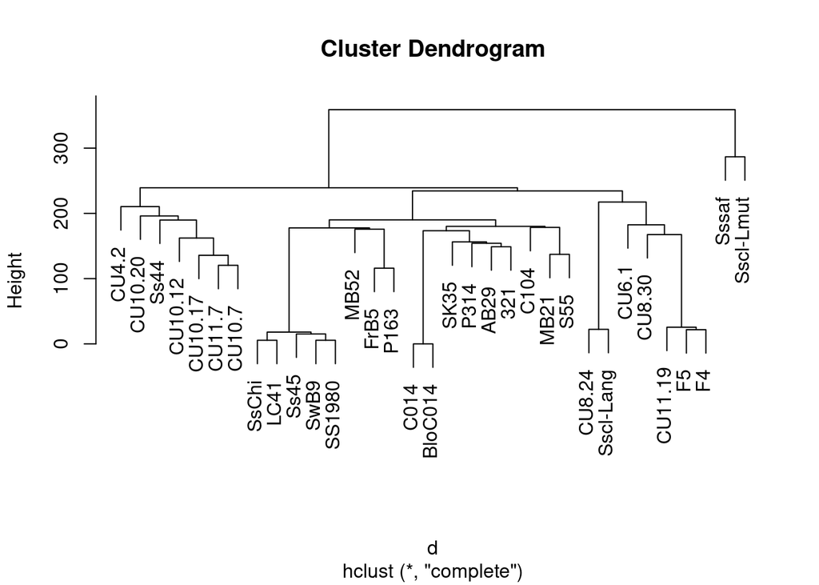

```r
mat <- as.data.frame(as.matrix(gt))
mat[["SS1980"]] <- 0
mat <- as.data.frame(t(mat))
mat <- rownames_to_column(mat, var = "id")

mat <- mat[mat$id != "SRR8485440", ]
mat <- mat[mat$id != "SRR8485438", ]
mat <- mat[mat$id != "SRR8485439", ]
mat <- mat[mat$id != "SRR8485442", ]

mat <- left_join(
  mat,
  reseq %>% select(id, accession),
  by = "id"
)

mat[mat$id == "SS1980", "accession"] <- "SS1980"
#mat[is.na(mat$id), "id"] <- mat[is.na(mat$id), "id"]

mat <- as.data.frame(mat)
row.names(mat) <- mat$accession
mat <- mat %>% select(-id, -accession)

d <- dist(mat)

hcl <- hclust(d)
plot(hcl)
```

Slightly concerningly, the 3 non-sclero isolates are placed pretty close to 1980 and Ss45.

```r
unlist(reseq[reseq$organism != "Sclerotinia sclerotiorum", "accession"])
```

```
## accession1 accession2 accession3
##    "SsChi"     "SwB9"     "LC41"
```

```r
reseq[reseq$accession == "Ss45", ]
```

```
## # A tibble: 1 × 15
##   sra    bioproject biosample DOI   url   platform read_length strategy organism
##   <chr>  <chr>      <chr>     <chr> <chr> <chr>          <dbl> <chr>    <chr>
## 1 SRR86… PRJNA5169… SAMN1084… http… <NA>  ILLUMINA         125 PE       Sclerot…
## # ℹ 6 more variables: accession <chr>, collection_host <chr>,
## #   collection_location <chr>, collection_year <dbl>, Notes <chr>, id <chr>
```

There are a lot of things that might be causing this problem, so I won’t worry too much just yet. We’ll select more strictly if we create a tree, which should avoid selective issues.

```r
write.vcf(vcf, "output/vcfr-filtered.vcf.gz")
```